# Red Wine Quality

Ahmed Eweed

June 9, 2018

# Introduction

This is one of two datasets involving red and white wine samples,  
Created by: Paulo Cortez (Univ. Minho), Antonio Cerdeira, Fernando Almeida,  
Telmo Matos and Jose Reis (CVRVV) @ 2009.  
It involves 1599 observations about 11 chemical features and  
an output result (quality) of the Portuguese “Vinho Verde” wine.  
Wine trade is huge around the world from planting grapes, fermentation and  
bottling of the finished liquid.  
I wondered which factor affects a wine taste and quality the most?  
Is that sugar, alcohol percentage or maybe it is one of the acids  
or other chemicals added to the wine through the production process.  
We will find out if my assumptions were right!

Citation: P. Cortez, A. Cerdeira, F. Almeida, T. Matos and J. Reis.  
Modeling wine preferences by data mining from physicochemical properties.

I will explore the distribution of the features across the dataset  
to see if there is any abnormal behaviours or misleading data

# Univariate Plots Section

```
## 'data.frame':    1599 obs. of  13 variables:
##  $ X                   : int  1 2 3 4 5 6 7 8 9 10 ...
##  $ fixed.acidity       : num  7.4 7.8 7.8 11.2 7.4 7.4 7.9 7.3 7.8 7.5 ...
##  $ volatile.acidity    : num  0.7 0.88 0.76 0.28 0.7 0.66 0.6 0.65 0.58 0.5 ...
##  $ citric.acid         : num  0 0 0.04 0.56 0 0 0.06 0 0.02 0.36 ...
##  $ residual.sugar      : num  1.9 2.6 2.3 1.9 1.9 1.8 1.6 1.2 2 6.1 ...
##  $ chlorides           : num  0.076 0.098 0.092 0.075 0.076 0.075 0.069 0.065 0.073 0.071 ...
##  $ free.sulfur.dioxide : num  11 25 15 17 11 13 15 15 9 17 ...
##  $ total.sulfur.dioxide: num  34 67 54 60 34 40 59 21 18 102 ...
##  $ density             : num  0.998 0.997 0.997 0.998 0.998 ...
##  $ pH                  : num  3.51 3.2 3.26 3.16 3.51 3.51 3.3 3.39 3.36 3.35 ...
##  $ sulphates           : num  0.56 0.68 0.65 0.58 0.56 0.56 0.46 0.47 0.57 0.8 ...
##  $ alcohol             : num  9.4 9.8 9.8 9.8 9.4 9.4 9.4 10 9.5 10.5 ...
##  $ quality             : int  5 5 5 6 5 5 5 7 7 5 ...
```

we can see 13 variables of 11 features and a result score (quality)  
plus a counter (X)

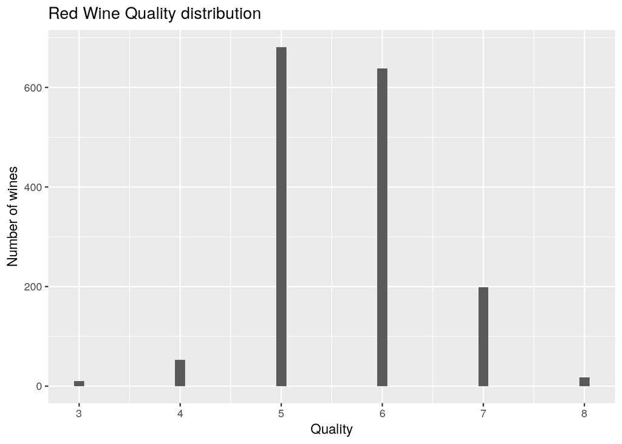

```
##    Min. 1st Qu.  Median    Mean 3rd Qu.    Max.
##   3.000   5.000   6.000   5.636   6.000   8.000
```

red Wine quality is normally distributed with mean of about 5.5

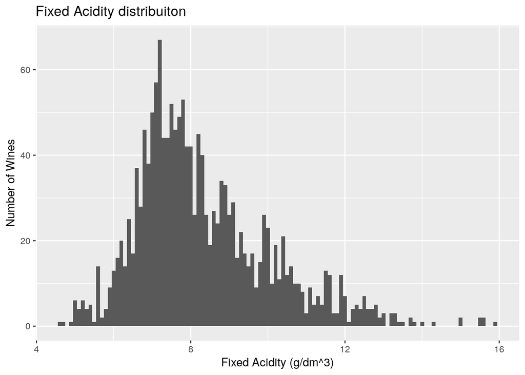

```
##    Min. 1st Qu.  Median    Mean 3rd Qu.    Max.
##    4.60    7.10    7.90    8.32    9.20   15.90
```

Fixed Acidity is skewed to the right with mean of 8

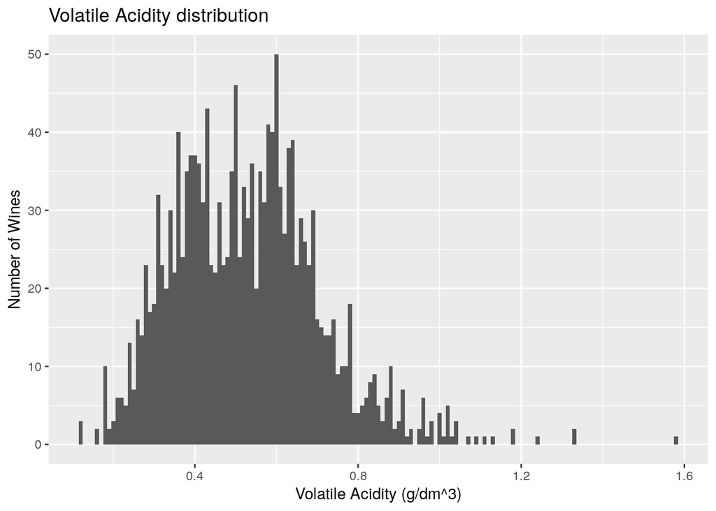

```
##    Min. 1st Qu.  Median    Mean 3rd Qu.    Max.
##  0.1200  0.3900  0.5200  0.5278  0.6400  1.5800
```

Volatile Acidity is skewed to the right with a mean of 0.5

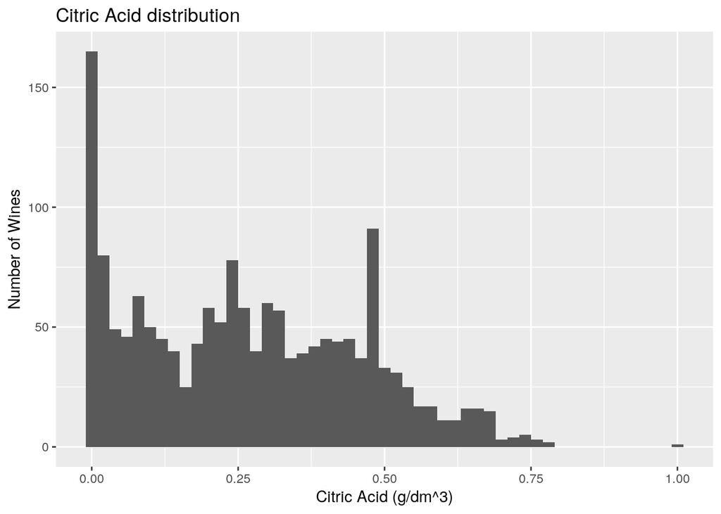

```
##    Min. 1st Qu.  Median    Mean 3rd Qu.    Max.
##   0.000   0.090   0.260   0.271   0.420   1.000
```

Citric Acid is not normally distributed!

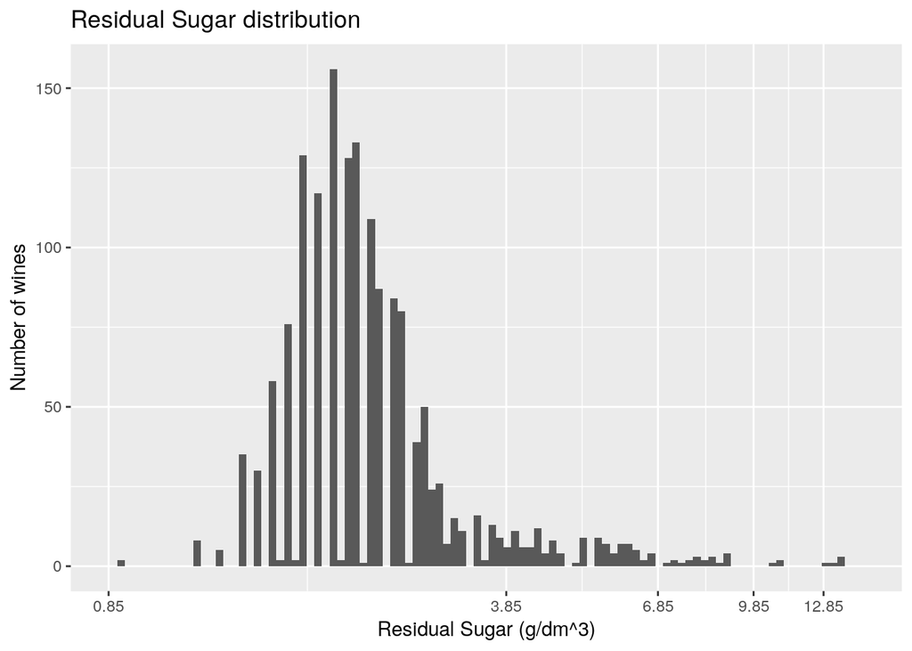

```
##    Min. 1st Qu.  Median    Mean 3rd Qu.    Max.
##   0.900   1.900   2.200   2.539   2.600  15.500
```

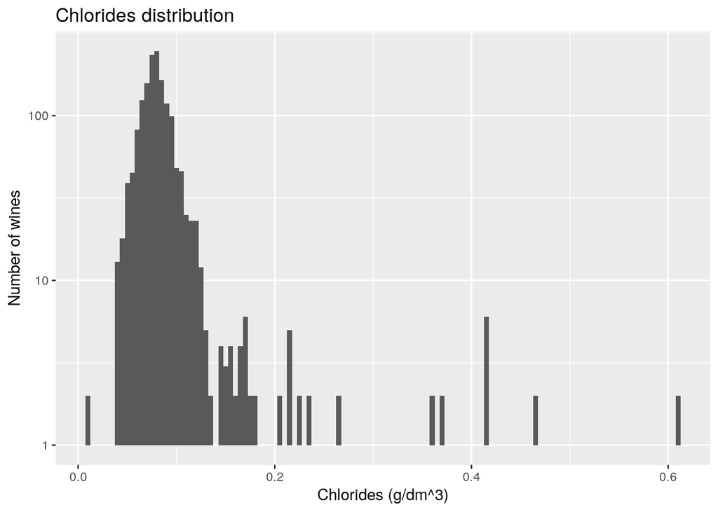

```
##    Min. 1st Qu.  Median    Mean 3rd Qu.    Max.
## 0.01200 0.07000 0.07900 0.08747 0.09000 0.61100
```

Chlorides are not normally distributed with mean of about 0.1  
and have many outliers

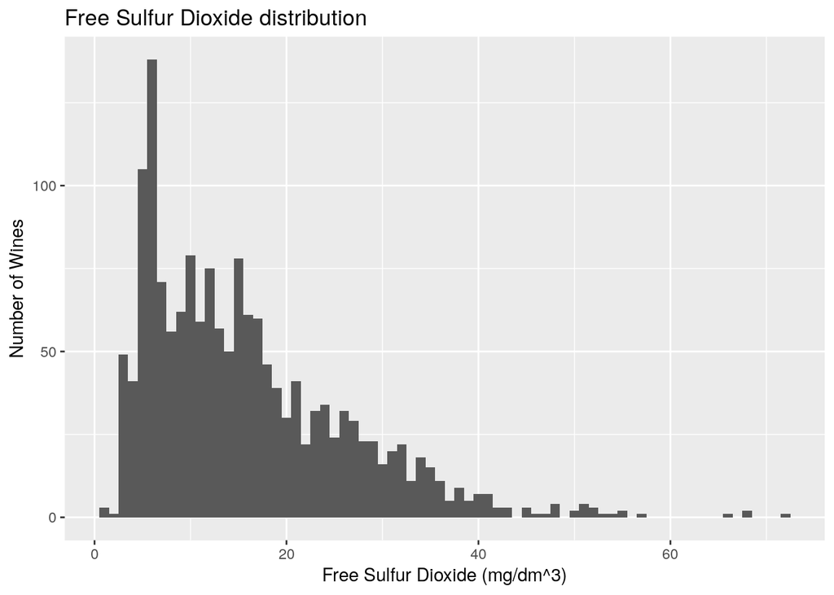

```
##    Min. 1st Qu.  Median    Mean 3rd Qu.    Max.
##    1.00    7.00   14.00   15.87   21.00   72.00
```

Free Sulfur Dioxide is skewed to the right with mean at 15

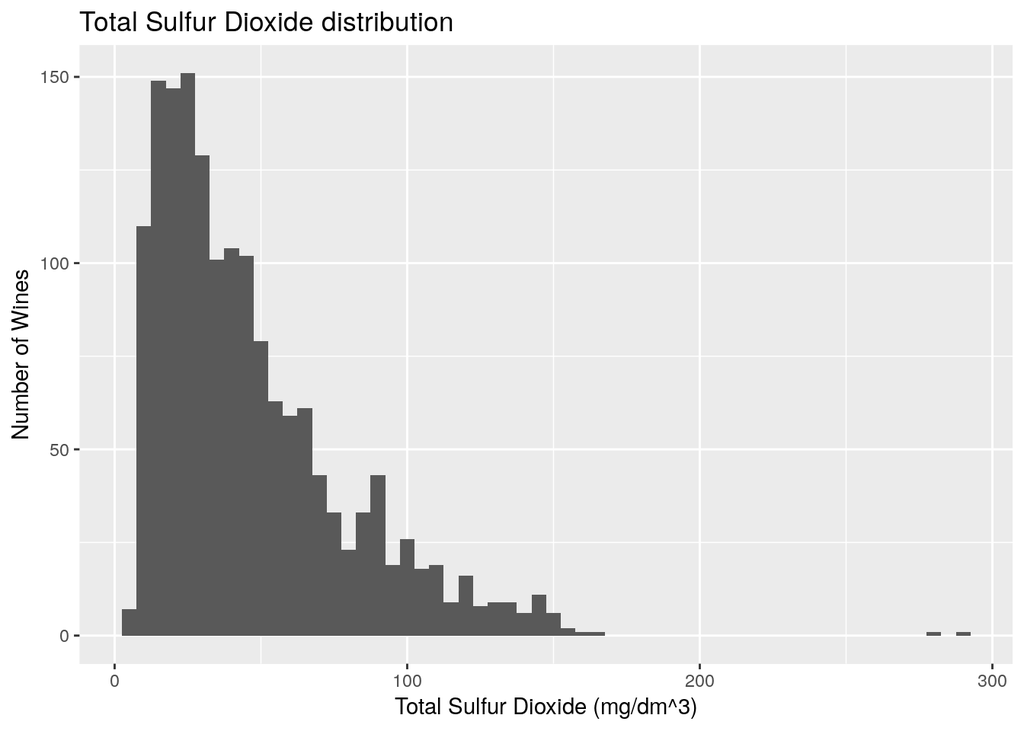

```
##    Min. 1st Qu.  Median    Mean 3rd Qu.    Max.
##    6.00   22.00   38.00   46.47   62.00  289.00
```

Total Sulfur Dioxide is skewed to the right with mean of 46

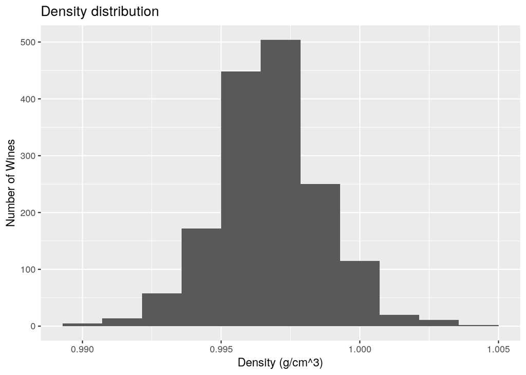

```
##    Min. 1st Qu.  Median    Mean 3rd Qu.    Max.
##  0.9901  0.9956  0.9968  0.9967  0.9978  1.0037
```

Density is normally distributed with mean of 0.99

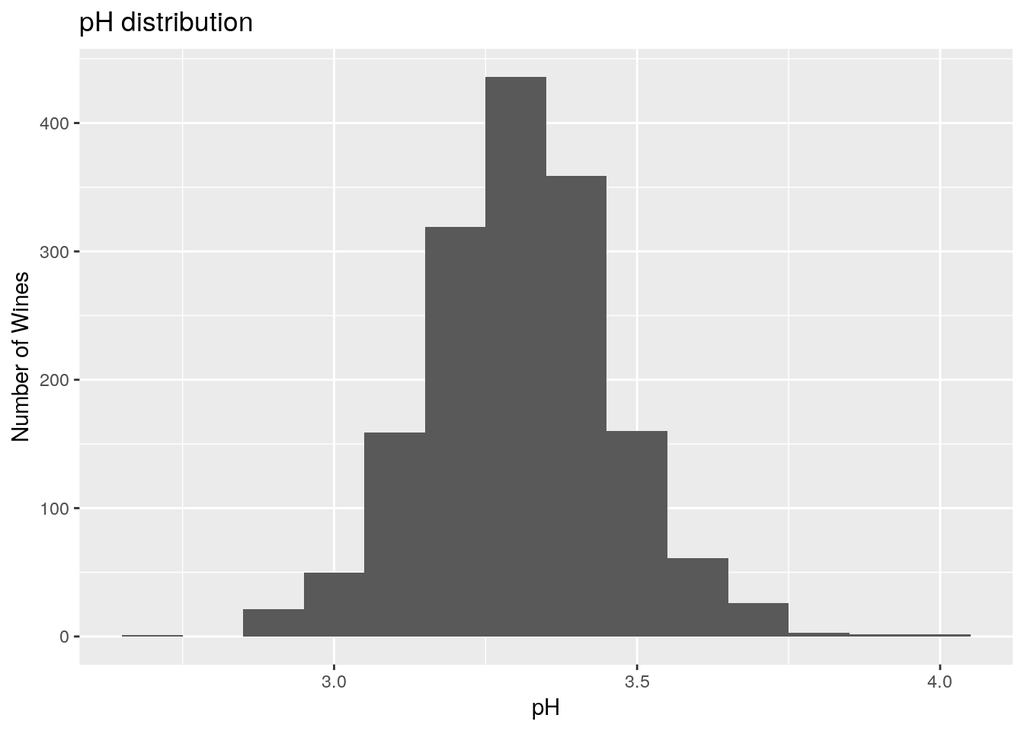

```
##    Min. 1st Qu.  Median    Mean 3rd Qu.    Max.
##   2.740   3.210   3.310   3.311   3.400   4.010
```

pH is normally distributed with mean of 3

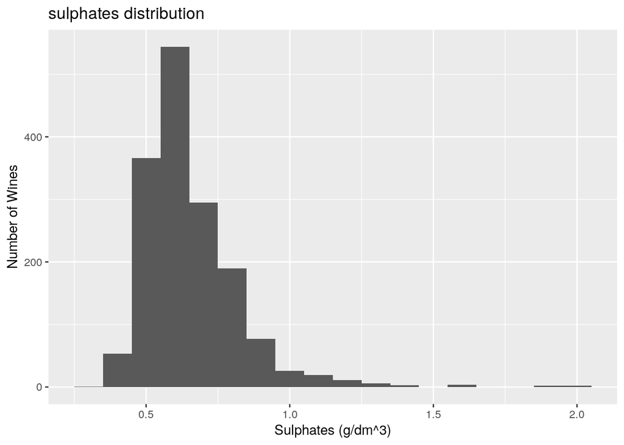

```
##    Min. 1st Qu.  Median    Mean 3rd Qu.    Max.
##  0.3300  0.5500  0.6200  0.6581  0.7300  2.0000
```

sulphates is skewed to the right with mean of 0.6

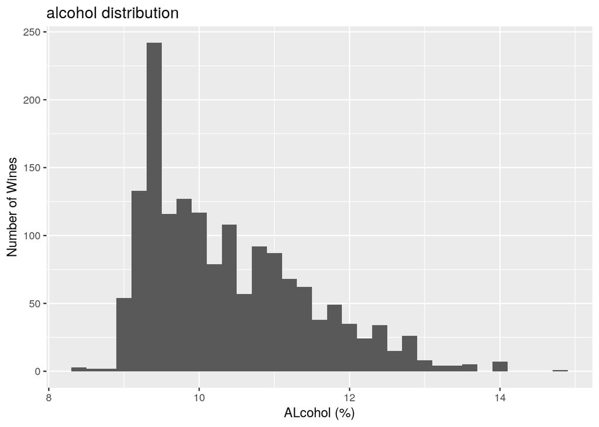

```
##    Min. 1st Qu.  Median    Mean 3rd Qu.    Max.
##    8.40    9.50   10.20   10.42   11.10   14.90
```

alcohol is skewed to the right with mean of 10

# Univariate Analysis

### What is the structure of your dataset?

We have 1599 observations with 13 variables, a counter (X), the result score (quality) and 11 chemical features as follows: (fixed acidity, volatile acidity, citric acid, residual sugar, chlorides, free sulfur dioxide, total sulfur dioxide, density, pH, sulphates, alcohol)

### What is/are the main feature(s) of interest in your dataset?

I found citric acid and volatile acidity interesting

### What other features in the dataset do you think

### will help support your investigation into your feature(s) of interest?

I think alcohol and sulphates will be interesting too

### Did you create any new variables from existing variables in the dataset?

no i didn’t

### Of the features you investigated, were there any unusual distributions?

### Did you perform any operations on the data to tidy, adjust,

### or change the form of the data?

### If so, why did you do this?

citric acid is not normally distibuted also Residual sugar is suspicious with alot of outlier data

yes, Chlorides and residual sugar was log transformed to avoid outlier presence

# Bivariate Plots Section

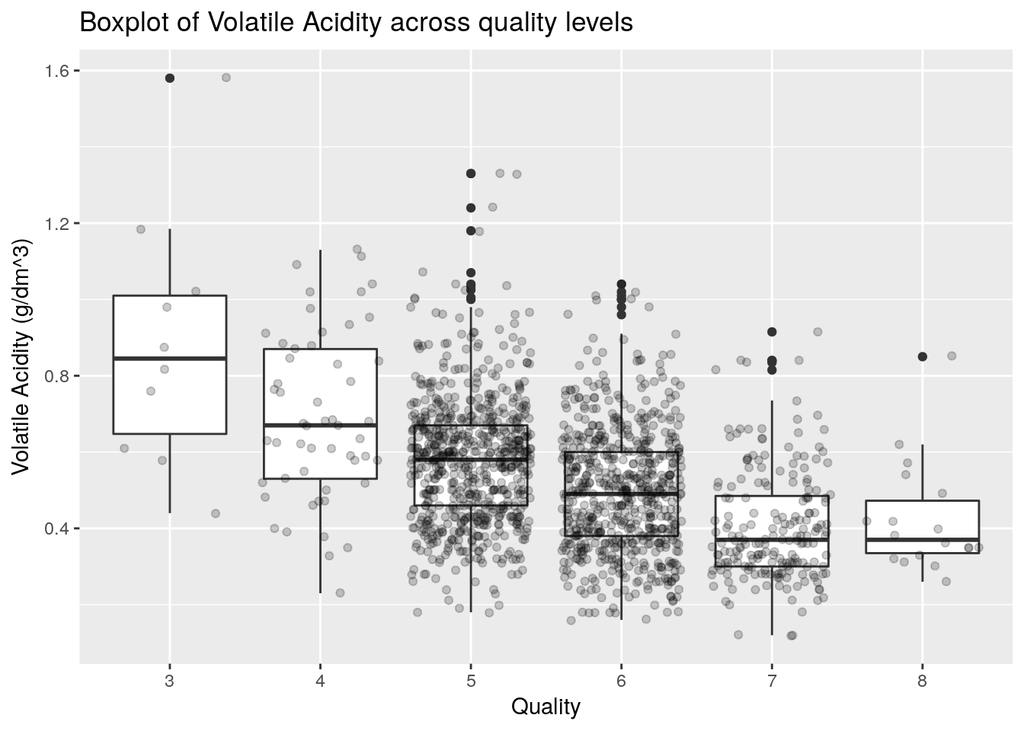

```
##
##  Pearson's product-moment correlation
##
## data:  rw$volatile.acidity and rw$quality
## t = -16.954, df = 1597, p-value < 2.2e-16
## alternative hypothesis: true correlation is not equal to 0
## 95 percent confidence interval:
##  -0.4313210 -0.3482032
## sample estimates:
##        cor
## -0.3905578
```

a weak negative correaltion (-0.39) exists between Quality and Volatile Acidity

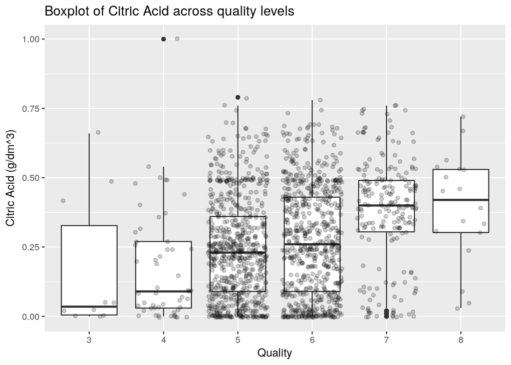

```
##
##  Pearson's product-moment correlation
##
## data:  rw$citric.acid and rw$quality
## t = 9.2875, df = 1597, p-value < 2.2e-16
## alternative hypothesis: true correlation is not equal to 0
## 95 percent confidence interval:
##  0.1793415 0.2723711
## sample estimates:
##       cor
## 0.2263725
```

a weak positive correaltion (0.22) exists between Quality and Citric Acid

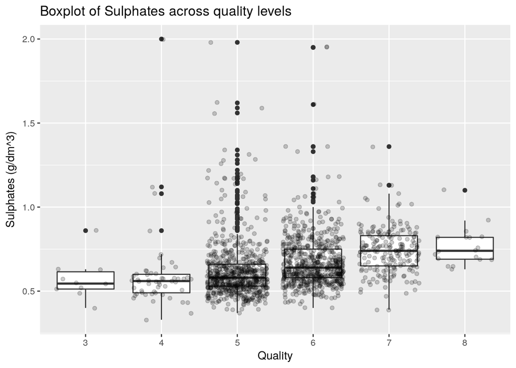

```
##
##  Pearson's product-moment correlation
##
## data:  rw$sulphates and rw$quality
## t = 10.38, df = 1597, p-value < 2.2e-16
## alternative hypothesis: true correlation is not equal to 0
## 95 percent confidence interval:
##  0.2049011 0.2967610
## sample estimates:
##       cor
## 0.2513971
```

a weak positive correaltion (0.25) exists between Quality and Sulphates  
many outliers exist too

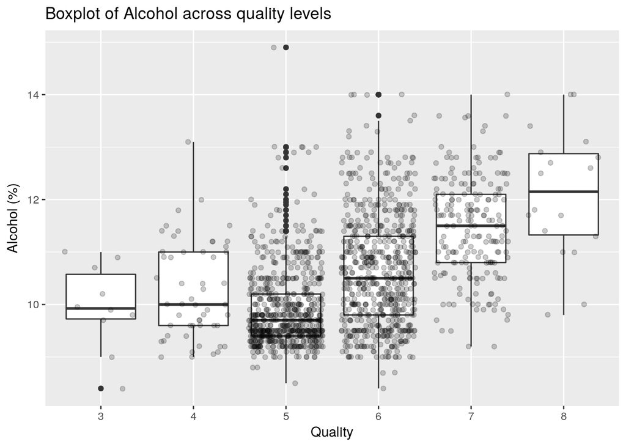

```
##
##  Pearson's product-moment correlation
##
## data:  rw$alcohol and rw$quality
## t = 21.639, df = 1597, p-value < 2.2e-16
## alternative hypothesis: true correlation is not equal to 0
## 95 percent confidence interval:
##  0.4373540 0.5132081
## sample estimates:
##       cor
## 0.4761663
```

a strong positive correaltion (0.47) exists between Quality and Alcohol

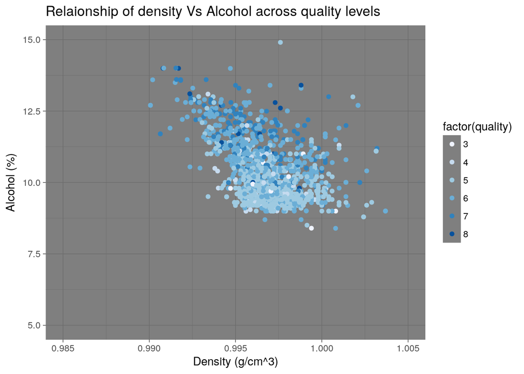

```
##
##  Pearson's product-moment correlation
##
## data:  rw$alcohol and rw$density
## t = -22.838, df = 1597, p-value < 2.2e-16
## alternative hypothesis: true correlation is not equal to 0
## 95 percent confidence interval:
##  -0.5322547 -0.4583061
## sample estimates:
##        cor
## -0.4961798
```

a strong negative correaltion (-0.49) exists  
between Density and Alcohol

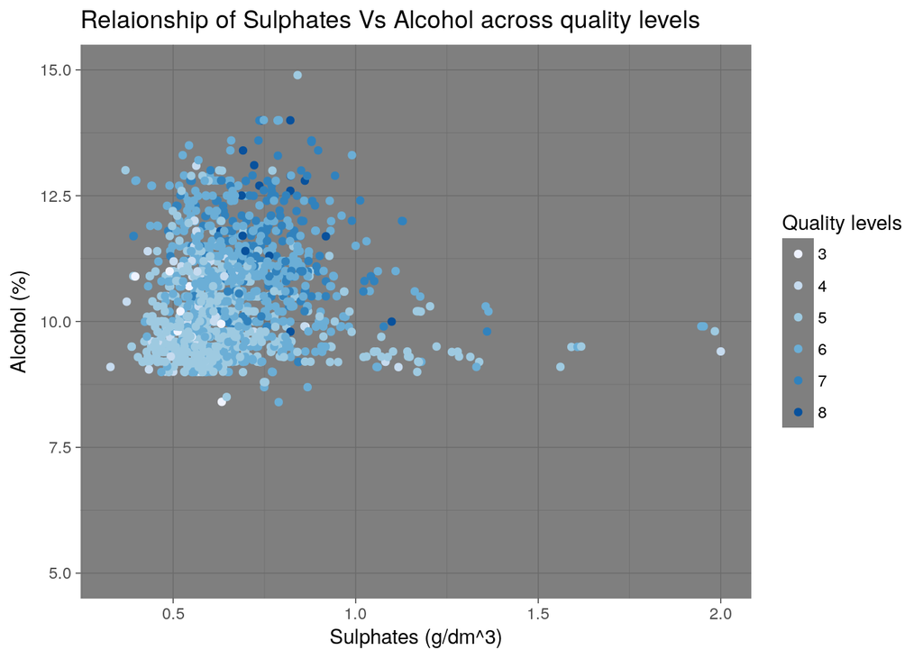

```
##
##  Pearson's product-moment correlation
##
## data:  rw$alcohol and rw$sulphates
## t = 3.7568, df = 1597, p-value = 0.0001783
## alternative hypothesis: true correlation is not equal to 0
## 95 percent confidence interval:
##  0.04477906 0.14196454
## sample estimates:
##        cor
## 0.09359475
```

there is almost no relationship between Alcohol and Sulphates

# Bivariate Analysis

### Talk about some of the relationships you observed in this part of the investigation.

### How did the feature(s) of interest vary with other features in the dataset?

there is negative relationship between quality and volatile acidity also volatile acidity and citric acid have negative relationship

there is positive relationship between quality and citric acid

# Multivariate Plots Section

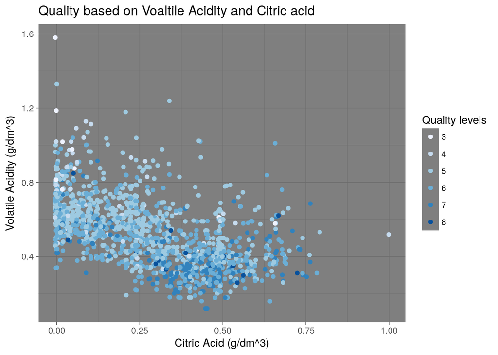

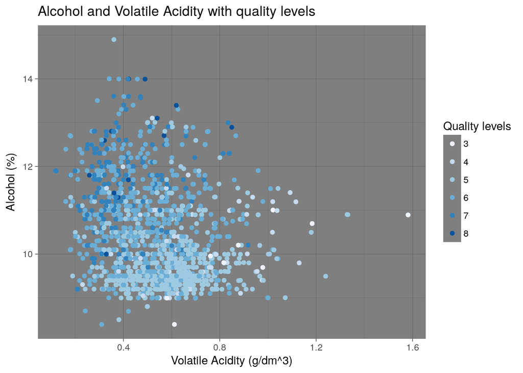

higher Alcohol content and moderate volatile acidity level  
relates to higher quality rates

# Multivariate Analysis

### Talk about some of the relationships you observed in this part of the investigation.

### Were there features that strengthened each other in terms of looking at your feature(s) of interest?

Volatile acidity and Citric Acid has a negaive relationship with each other and the less the Volatile acid and the more Citric Acid in the wine,  
the higher rate it takes

### OPTIONAL: Did you create any models with your dataset? Discuss the strengths and limitations of your model.

# Final Plots and Summary

### Plot One

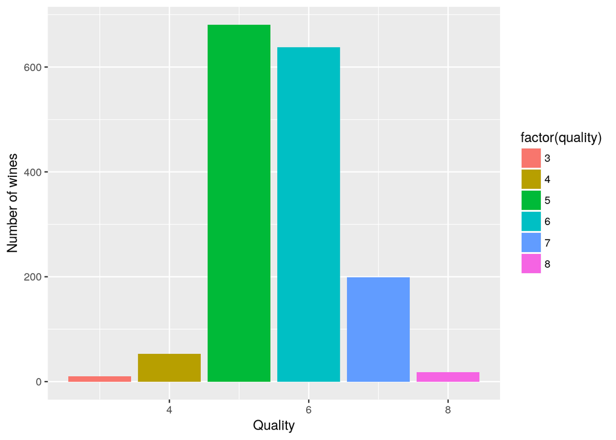

### Description One

red wine quality is normally distributed with almost no wine rated 0,1,2 and 9  
wine rate(worst—-> best):  
3 - 4 - 5 - 6 - 7 - 8

### Plot Two

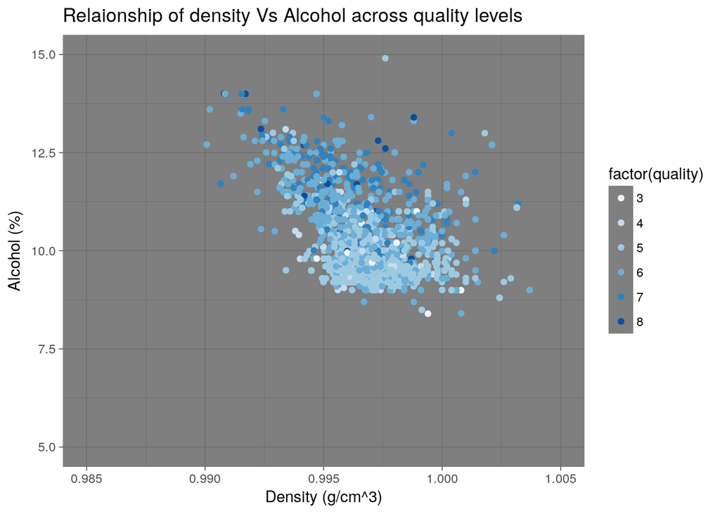

### Plot Three

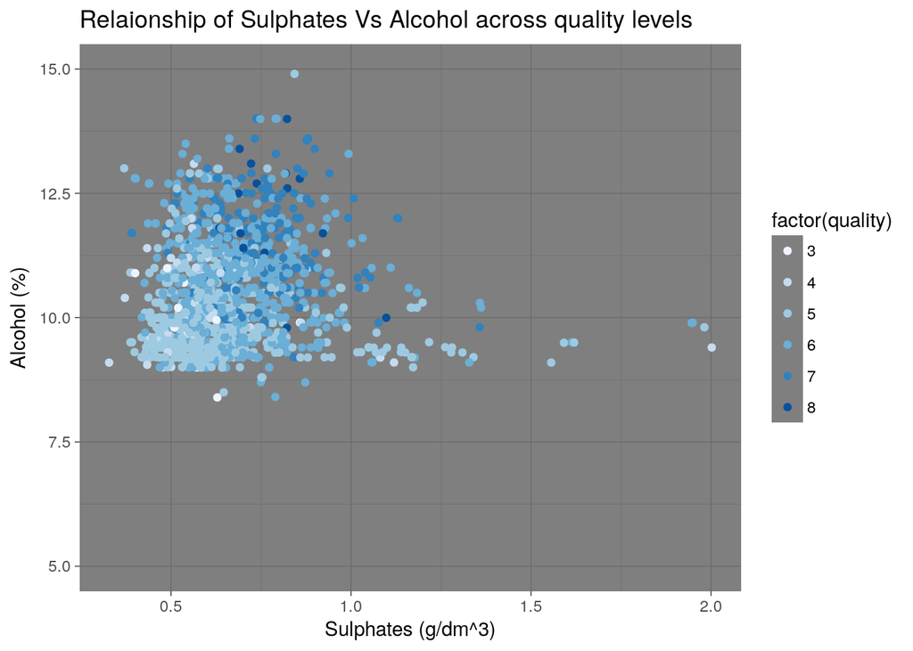

### Description Three

sulphates between 0.6 and 0.82 g/dm^3 and alcohol between 10 and 14 percent  
has the highest quality rate

# Reflection

Red Wine has very interesting quality factors I had much fun exploring the dataset and discovering new relations between features  
it was hard to pick the right features as all features are almost chemical  
but, with some research and collecting data about wine production,  
I managed to detect the right ones, or so I thought!  
unfortunatelly, we should have more samples to make the best prediction of them  
As Residual sugar surprisingly was ineffective in determining the quality of wine I think more features are necessary to be collected to determine wine quality not only chemical ones, but also grape kind and conditions of storing It was an interesting experience as well.